# Ordenamiento Bases de datos

## Estimación Stanging stock

### Bases de datos

A partir de diferentes proyectos desde el años 2012 a la fecha se obtuvo información de la estructura de tallas de L. trabeculata.

### 2012-2014

Primera base de datos proviene de un proyecto fondecytF11110351, y tiene información obtenida en terreno de las temporadas de otoño y primavera en los años 2012-2013 y para la temporada de verano del año 2014.

Los monitoreos se realizaron a través de 2 transectos de 100 m perpendiculares a la costa, donde se evaluó la abundancia y diámetro del disco de las macroalgas en cuadrantes de 1m<sup>2</sup> a cada lado del transecto en estaciones cada 10 m.

### 2015

La segunda base de datos proviene del proyecto fondecyt F1140841 donde se realizó un sólo muestreo durante la temporada de verano 2015, en transectos de 50 m perpendiculares a la costa, donde se medió la abundancia de algas y morfología de las algas (incluyendo el diámetro del disco) en cuadrantes de 1m<sup>2</sup> a cada lado del transecto en estaciones cada 10 m.

### 2015-2017

La tercera base de datos proviene del proyecto fondecyt 1151094 donde se realizaron muestreos en dos localidades de la V región, Quintay y Los Molles. En cada sitio se realizaron monitoreos en una zona expuesta y en una zona protegida. En cada zona se muestrearon las algas en cuadrantes de 1m2, en 6 transectos de 25 m perpendiculares a la costa, 3 fueron realizados en zonas profundas (15 m) y 3 en zonas someras (5m). Los cuadrantes fueron dispuestos en estaciones cada 5 metros.

#### Variación latitudinal y temporal 2012-2013

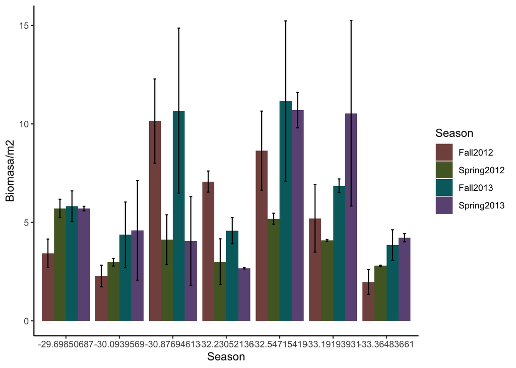

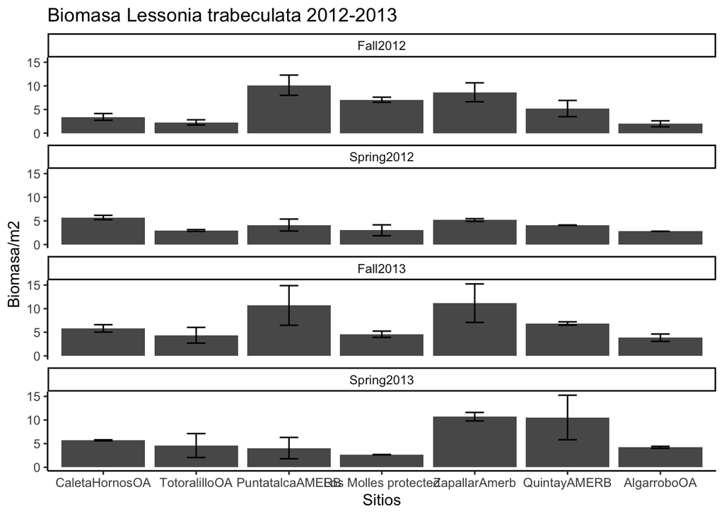

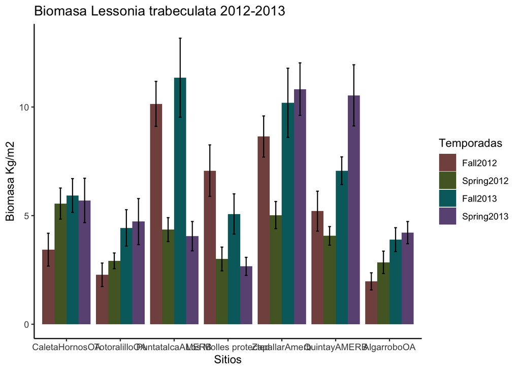